# Gene set testing and correlations

Michael Love  
June 8, 2015

### Gene set tests with correlation

(from [PH525x notes](http://genomicsclass.github.io/book/pages/gene_set_analysis.html) and [Barry, Nobel and Wright, 2008](http://arxiv.org/abs/0803.3881))

Consider the average *t*-statistic from \( N \) genes in a set \( G \):

\[ \bar{t}=\frac{1}{N} \sum_{i \in G} t_i \]

This statistic \( \bar{t} \) combines the information about DE from the set and might be a useful test statistic.

### Gene set tests with correlation

Under the null hypothesis, the \( t \) have mean 0. If the \( t \) are independent then \( \sqrt{N} \bar{t} \) has standard deviation 1 and is approximately normal:

\[ \sqrt{N} \bar{t} \sim N(0,1) \]

This comes from the following decomposition of the variance:

\[ \begin{eqnarray} \text{Var}(\bar{t}) &=& \frac{1}{N^2} \text{Var}(t_1 + \dots + t_N) \\ &=& \frac{1}{N^2}( \text{Var}(t_1) + \dots + \text{Var}(t_N) ) \\ &=& \frac{1}{N} \end{eqnarray} \]

### Gene set tests with correlation

Now consider the case that the test statistics \( t_i \) in a gene set are not independent but have correlation \( \rho \) *under the null hypothesis*.

\[ \bar{t}=\frac{1}{N} \sum_{i \in G} t_i \]

\[ \text{corr}(t_i, t_{i'}) = \rho, \quad i, i' \in G \]

The variance of the average *t*-statistics will be:

\[ \begin{eqnarray} \text{Var}(\bar{t}) &=& \frac{1}{N^2} \text{Var}( (1 \dots 1) (t_1 \dots t_N)' ) \\ &=& \frac{1}{N^2}(1 \dots 1) \begin{pmatrix} 1 & \rho & \dots & \rho & \rho \\ \rho & 1 & \rho & \dots & \rho \\ \dots & \dots & \dots & \dots & \dots \\ \rho & \rho & \dots & \rho & 1 \\ \end{pmatrix} (1 \dots 1) ' \\ &=& \frac{1}{N^2}\{N + (N-1) N \rho \} \\ &=& \frac{1}{N}\{1 + (N-1) \rho \} \end{eqnarray} \]

### Variance inflation with correlation

So the variance inflation factor (VIF) comparing the independent case to the case with correlation is:

\[ VIF = 1 + (N-1) \bar{\rho} \]

So the increased width (standard deviation) of the null distribution for a gene set with 20 genes and average correlation 0.1 will be:

```r
sqrt(1 + 19 * 0.1)
```

```
[1] 1.702939
```

This VIF is approximately true also for testing the set statistics against the complement: the genes not in the set (see Barry, Nobel and Wright 2008).

### Test statistic vs expression correlations

Here, the expression of 5 samples vs 5 samples, no true difference but a correlation of gene expression.

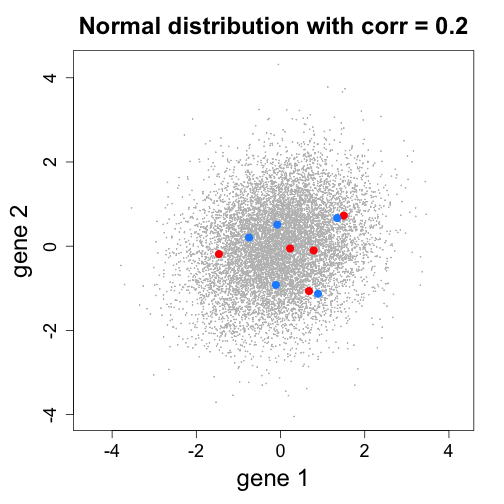

### Test statistic vs expression correlations

If the test statistic \( T \) is a linear form of the data \( X \) (e.g. log fold change), then:

\[ \rho^T_{i,i'} = \rho^X_{i,i'} \]

For t-test, the relationship is monotone, approximately linear and:

\[ \rho^T_{i,i'} \approx \rho^X_{i,i'} \]

(Barry, Nobel and Wright, 2008)

### Simulate expression correlation of 0.2

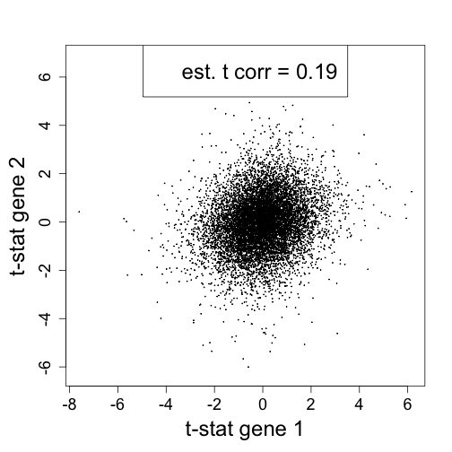

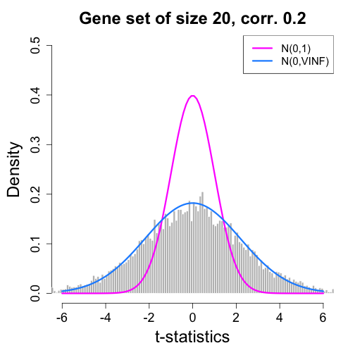

28% of the simulated t-statistics are outside of the center 99% of the \( N(0,1) \) distribution.

### Whence correlations?

Where do expression correlations *under the null* come from? My guesses in order of importance:

- uncorrected batch effects
- large scale amplifications in cancer
- gene regulatory networks

### CAMERA (Wu and Smyth 2012)

for **C**orrelation **A**djusted **ME**an **RA**nk gene set test, available in the limma package.

- estimating the inter-gene correlation from the data
- using it to adjust the gene set test statistic
- suitable for any experiment that can be represented by genewise linear models

### Permutations

Assume the null: no differences across condition, although gene-gene correlation are present

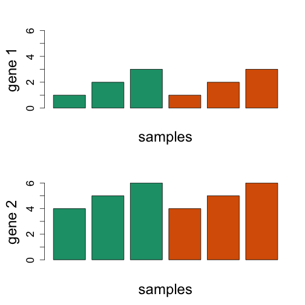

### Permutations

Assume the null: no differences across condition, although gene-gene correlation are present

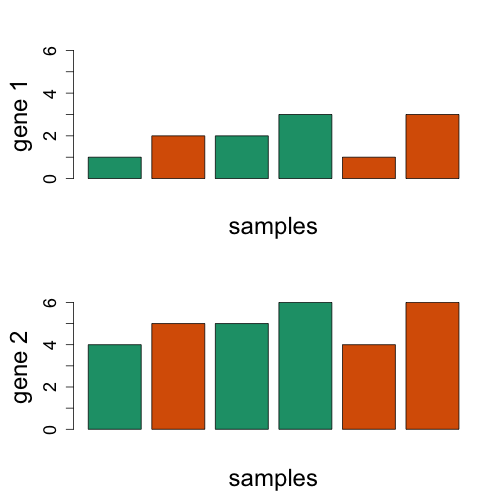

### Permutations

Has limitations:

- only if samples are exchangeable (no batch effects)
- not easy to implement for complex designs (although see [samr](http://cran.r-project.org/web/packages/samr/index.html) for strategies)
- requires sufficient samples for small p-values (although see [Larsen and Owen](http://arxiv.org/abs/1405.1383) for moment-based trick)

### Approach using residuals

Suppose we have a 2 condition experiment with 2 batches:

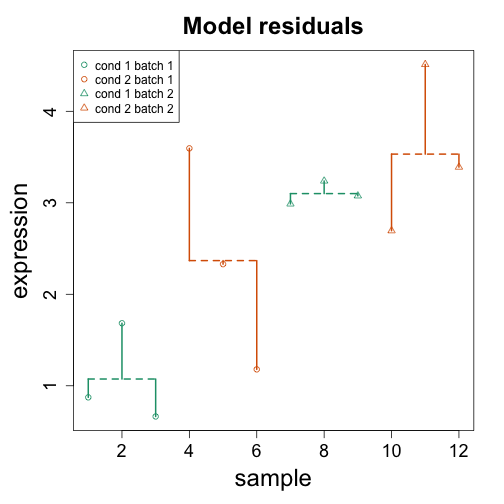

### Approach using residuals

Remove design matrix columns not involving the null hypothesis:

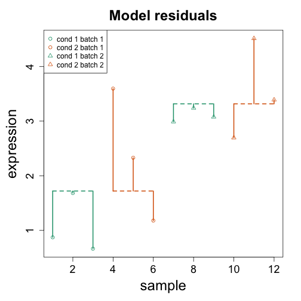

### ROAST (Wu et al. 2010)

The ROAST method available in the limma package:

Under the null hypothesis (and assuming a linear model) the residuals are independent and identically distributed \( N(0, \sigma_g^2) \).

We can *rotate* the residual vector for each gene in a gene set, such that gene-gene expression correlations are preserved.

### What does residual rotation look like?

Like this diagram but around an n-sphere (n, the number of samples).

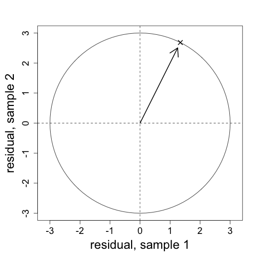

### ROAST (Wu et al. 2010)

Repeat 10,000 times:

1. rotate the residual vector from each gene in the set using the same rotation
2. create new data, preserving the gene-gene correlations
3. compute test statistics for the rotated data for each gene and compute the gene set statistic

Lastly compare the original gene set statistic to the null distribution from 1-3.

Pros: fast and efficient, fits with any linear model

### Summary

1. Gene-gene correlations inflate the null distribution of gene set statistics
2. This inflation factor can be directly calculated from the data
3. Rotating residuals can also be used to generate a null which incoroporates correlations